# This Program perform multi label Image Classification of statellite images using fastai libraries

#### The program identifies various features of a staellite picture (https://www.kaggle.com/c/planet-understanding-the-amazon-from-space)

#### This program is written for Python version 3

###### The program for Binary image classfication from https://github.com/anandpuntambekar/Dog_breeds_class has been appended for the same

```python
#To auto-reload modules in jupyter notebook (so that changes in files *.py doesn't require manual reloading):
%reload_ext autoreload
%autoreload 2

#To inline the output of plotting commands is displayed inline within frontend Jupyter notebook
%matplotlib inline

# similar to Binary image classification
```

```python
# Confirm Python Version 3
from platform import python_version
print(python_version())

# similar to Binary image classification
```

```
3.6.7
```

```python
#Change working Directory to import Fastai libraries, loaction of fastai modules
import os
os.chdir('/home/paperspace/fastai/courses/dl1/fastai')
%pwd
```

[output not shown]

```python
# Uodate models of fast AI
#!wget http://files.fast.ai/models/weights.tgz
#!tar -xvzf weights.tgz
```

```python
#Change working Directory to import Fastai libraries, loaction of fastai modules
os.chdir('/home/paperspace/fastai/courses/dl1')
%pwd

# similar to Binary image classification, however working dir needs to change
```

```
'/home/paperspace/fastai/courses/dl1'
```

```python
# Import all main extrnal libraries
from fastai.imports import *
```

```python
# Manage transformation library written from scratch in PyTorch.
# The main purpose of the library is for data augmentation, also use it for more general image transformation purposes
from fastai.transforms import *

# Get a pre-trained model with the fast ai library
from fastai.conv_learner import *

# DL models by fastai (http://files.fast.ai/models/)
from fastai.models import *

# Module has the necessary functions to be able to download several useful datasets
from fastai.dataset import *

# Module to reform SGDR
from fastai.sgdr import *

# Module to display plots - such as larning rate
from fastai.plots import *

# similar to Binary image classification
```

```python
# Additional imports for Multicalss image classifcation

from fastai.imports import *
from fastai.torch_imports import *
```

- 'sz' is size of images, should be changed in order to perform fast training

```python
#Path is path to Data, path variable needs to change
PATH= '/home/paperspace/fastai/courses/SelfCodes/Space_Amazon_Image/data/'

# One should start with small size, once results improve saizes can be increased
sz=224
arch = resnet34
f_model = arch
bs=58 # start from 28
```

```python
# NVidia GPU with programming framework CUDA is critical & following command must return true
torch.cuda.is_available()
```

```
True
```

```python
# Make sure deep learning package from CUDA CuDNN is enabled for improving training performance ( prefered)
torch.backends.cudnn.enabled
```

```
True
```

```python
# Additional comment for multiclass calssification code from fastai

torch.cuda.set_device(0)
```

#### Confirm the product structure of PATH - for binay image classification

- Path needs to have 'train' and 'valid' folders , both folders subfoders with 'cats' & 'dogs'
- 'tmp' shall store precompute activations
- for debugging we may delete contents of 'tmp'
- 'models' folder shall save trained models

#### Confirm the product structure for dogbreed image classifcation

- Instead of train folder which has a separate folder for each breed of dog, it has a CSV file with the correct labels

```python
# list of files in PATH
os.listdir(PATH)
```

```
['test_v2_file_mapping.csv',
 '.ipynb_checkpoints',
 'train-jpg',
 'test-jpg-additional',
 'test-jpg',
 'sample_submission_v2.csv',
 '__MACOSX',
 'train_v2.csv',
 '.kaggle-cli']
```

```python
# code for binay classification and train valid splif fies
# list directories of 'PATH'
# os.listdir(f'{PATH}valid')
```

```python
# This is a little bit different to our previous dataset.
# Instead of train folder which has a separate folder for each breed of dog, it has a CSV file with the correct labels


# Open CSV file, create a list of rows, then take the length. -1 because the first row is a header.
# Hence n is the number of images we have.

# Command to open CSV files
#label_csv = f'{PATH}labels.csv'

# number of total rows minus the header
#n = len(list(open(label_csv)))-1
#print (n)

# Creation of rows for validation set, default = 20%
# “get cross validation indexes” — this will return, by default, random 20% of the rows (indexes to be precise)
# to use as a validation set.
# You can also send val_pct to get different amount.
#val_idxs = get_cv_idxs(n)
#print(len(val_idxs))
```

```python
# Code for Satellile Mulilabel

label_csv = f'{PATH}train_v2.csv'
n = len(list(open(label_csv)))-1
print (n)

val_idxs = get_cv_idxs(n)
print(len(val_idxs))

#Multi-label classification cannot be done with Keras style approach where subfolder is the name of the label.
#So we use from_csv
```

```
40479
8095
```

# Initial exploration

```python
# Code for Satellile Mulilabel
def get_1st(path): return glob(f'{path}/*.*')[0]
```

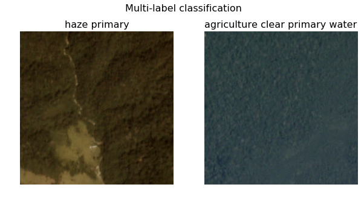

```python
# Code for Satellile Mulilabel
list_paths = [f"{PATH}train-jpg/train_4.jpg", f"{PATH}train-jpg/train_11.jpg"]
titles=["haze primary", "agriculture clear primary water"]
plots_from_files(list_paths, titles=titles, maintitle="Multi-label classification")
```

In multi-label classification each sample can belong to one or more classes. In the previous example, the first image belongs to two classes: haze and primary. The second image belongs to four classes: agriculture, clear, primary and water.

```python
# code selected for Binary image classification
# Observe file names
#os.listdir(f'{PATH}valid/cats')[0]
```

```python
# code selected for Binary image classification
# observe cat picture
#img = plt.imread(PATH + 'valid/cats/' + os.listdir(f'{PATH}valid/cats')[0])
#plt.imshow(img);
```

```python
# Code for Multi  breed classification
#label_df = pd.read_csv(label_csv)
#label_df.head()
```

```python
# Code for Multi  breed classification
#label_df.pivot_table(index='breed', aggfunc=len).sort_values('id', ascending=False)
```

```python
# different architectures have different number of layers, size of kernels, filters, etc.
# We have been using ResNet34 — a great starting point and often a good finishing point
# because it does not have too many parameters and works well with small dataset.
# here is another architecture called ResNext which was the second-place winner in last year’s ImageNet competition.
# ResNext50 takes twice as long and 2–4 times more memory than ResNet34.


#tfms = tfms_from_model(arch, sz, aug_tfms=transforms_side_on, max_zoom=1.1)
#data = ImageClassifierData.from_csv(PATH, 'train', f'{PATH}labels.csv', test_name='test', val_idxs=val_idxs, suffix='.jpg', tfms=tfms, bs=bs)

# max_zoom — we will zoom in up to 1.1 times

# ImageClassifierData.from_csv — last time, we used from_paths but since the labels are in CSV file, we will call from_csv instead.

#test_name — we need to specify where the test set is if you want to submit to Kaggle competitions

#val_idx — there is no validation folder but we still want to track how good our performance is locally.
```

Instead of accuacy, we used F-beta for this notebook — it is a way of weighing false negatives and false positives. The reason we are using it is because this particular Kaggle competition wants to use it. Take a look at planet.py to see how you can create your own metrics function. This is what gets printed out at the end [ 0. 0.08932 0.08218 0.9324 ]

```python
# Code for Satellile Mulilabel
from planet import f2

metrics=[f2]
```

```python
# Code for Satellile Mulilabel

def get_data(sz):
    tfms = tfms_from_model(f_model, sz,
        aug_tfms=transforms_top_down, max_zoom=1.05)
    return ImageClassifierData.from_csv(PATH, 'train-jpg',
               label_csv, tfms=tfms, suffix='.jpg',
               val_idxs=val_idxs, test_name='test-jpg')

#transform_top_down : it does more than just a vertical flip.
# There are 8 possible symmetries for a square — it can be rotated through 0, 90, 180, 270 degrees and for each of those,
#it can be flipped (dihedral group of eight)
```

```python
# Code for Satellile Mulilabel
data = get_data(256)
```

dl is a data loader which will give you a mini-batch, specifically transformed mini-batch. With a data loader, you cannot ask for a particular mini-batch; you can only get back the next mini-batch. In Python, it is called “generator” or “iterator”. PyTorch really leverages modern Python methodologies.

```python
# Code for Satellile Mulilabel
#x : a mini-batch of images, y : a mini-batch of labels.
x,y = next(iter(data.val_dl))
```

```python
# You can access to training dataset by saying data.trn_ds and trn_ds contains a lot of things including file names (fnames)

#fn = PATH + data.trn_ds.fnames[0]; fn
```

```python
#img = PIL.Image.open(fn); img
```

```python
#img.size
```

```python
# code selected for Binary image classification
# Observe img shape
#img.shape
```

```python
# Code for Satellile Mulilabel
list(zip(data.classes, y[0]))
```

```
[('agriculture', 1.0),
 ('artisinal_mine', 0.0),
 ('bare_ground', 0.0),
 ('blooming', 0.0),
 ('blow_down', 0.0),
 ('clear', 1.0),
 ('cloudy', 0.0),
 ('conventional_mine', 0.0),
 ('cultivation', 0.0),
 ('habitation', 0.0),
 ('haze', 0.0),
 ('partly_cloudy', 0.0),
 ('primary', 1.0),
 ('road', 0.0),
 ('selective_logging', 0.0),
 ('slash_burn', 0.0),
 ('water', 1.0)]
```

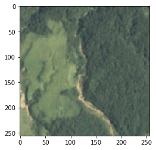

```python
# Code for Satellile Mulilabel
plt.imshow(data.val_ds.denorm(to_np(x))[0]*1.4);

#*1.4 : The image was washed out, so making it more visible (“brightening it up a bit”).
# Images are just matrices of numbers, so we can do things like this.
```

```python
# Now we check image size. If they are huge, then you have to think really carefully about how to deal with them.
# If they are tiny, it is also challenging. Most of ImageNet models are trained on either 224 by 224 or 299 by 299 images
# Dictionary comprehension — key: name of the file, value: size of the file
#size_d = {k: PIL.Image.open(PATH+k).size for k in data.trn_ds.fnames}

# *size_d.values() will unpack a list. zip will pair up elements of tuples to create a list of tuples.
#row_sz, col_sz = list(zip(*size_d.values()))

#row_sz = np.array(row_sz)
#col_sz = np.array(col_sz)
```

```python
#row_sz[:5]
```

```python
#plt.hist(row_sz)
```

```python
#plt.hist(row_sz[row_sz<1000])
```

```python
#plt.hist(row_sz)
```

```python
#plt.hist(col_sz[col_sz<1000])
```

```python
#len(data.trn_ds), len(data.test_ds)
```

We will not use sz=64 for cats and dogs competition because we started with pre-trained ImageNet network which starts off nearly perfect. If we re-trained the whole set with 64 by 64 images, we would destroy the weights that are already very good. Remember, most of ImageNet models are trained with 224 by 224 or 299 by 299 images. There is no images in ImageNet that looks like the one above. And only the first couple layers are useful to us. So starting out with smaller images works well in this case

After the assignment, tfms will pass to the data loader ImageClassifierData.from_csv(...). One of the things the data loader does is to resize the images on the fly. In other words, the images go into the data loader in full size, and it ONLY resizes the image when it outputs them to the model via Python’s generator.

Notice calling data.resize(int(sz *1.3), 'tmp') allow us to resize the images in advanced. Here, data.resize() takes a maximum size (e.g. sz=64, so the maximum size is int(sz* 1.3) = 83), so each image has dimension bigger than sz *1.3 will be resized. Since images can be rectangular, data.resize() will make sure the smallest dimension to be sz* 1.3 and center-crop it.

Importantly, it creates a resized copy of the entire dataset to a temporary folder tmp.

This technique will save you a lot of time because according to Jeremy, if you have large images, say 1000 by 1000, reading the images and resizing it to 64 by 64 before doing SGD during training will take more time than training the convolution nets alone! By calling data.resize() in advanced, we can resize the images once and do SGD multiple times efficiently.

```python
# # Code for Satellile Mulilabel
sz=64
data = get_data(sz)
data = data.resize(int(sz*1.3), 'tmp')
```

One of the things the data loader does is to resize the images on-demand. This has nothing to do with data.resize . If the initial image is 1000 by 1000, reading that JPEG and resizing it to 64 by 64 take more time than training the convolutional net. data.resize tells it that we will not use images bigger than sz*1.3 so go through once and create new JPEGs of this size. Since images are rectangular, so new JPEGs whose smallest edge is sz*1.3 (center-cropped). It will save you a lot of time.

## 1 Develop model

We shall use pretrained CNN model developed on imagenet to solve similar problem we shall use resnet34 (deep residual network (deep ResNet) is a type of specialized neural network that helps to handle more sophisticated deep learning tasks and models.)

```python
# Uncomment the below if you need to reset your precomputed activations
# shutil.rmtree(f'{PATH}tmp', ignore_errors=True)
```

```python
# code selected for Binary image classification

# arch=resnet34

#https://forums.fast.ai/t/precompute-true/7316/50

# At this point, your data (images) are formatted according to your pre-trained model (arch) and preferences (sz, DA, zoom…),
# and they are ready-to-be used
#data = ImageClassifierData.from_paths(PATH, tfms=tfms_from_model(arch,sz))


#At its creation (ie, when you run the code above : learn = ...) and by default,
# the new NN freezes the first layers (the ones from arch) and downloads the pre-trained weights of arch.
# More, precompute=False by default. Therefore, you must precise precompute=True if you want to change the default behavior.
#learn = ConvLearner.pretrained(arch,data,precompute=True)

# At this point (precompute=True and first layers frozen), only the last layers of your new NN will be trained
# (ie, their weights will be updated in order to minimize the loss of the model).
#learn.fit(0.01,2)
```

```python
#Source:
    def resize(self, targ, new_path):
        new_ds = []
        dls = [self.trn_dl,self.val_dl,self.fix_dl,self.aug_dl]
        if self.test_dl: dls += [self.test_dl, self.test_aug_dl]
        else: dls += [None,None]
        t = tqdm_notebook(dls)
        for dl in t: new_ds.append(self.resized(dl, targ, new_path))
        t.close()
        return self.__class__(new_ds[0].path, new_ds, self.bs, self.num_workers, self.classes)
#File:      ~/fastai/courses/dl1/fastai/dataset.py
```

```python
# When we start working with new dataset, we want everything to go super fast.
# So we made it possible to specify the size and start with something like 64 which will run fast.
#Later, we will use bigger images and bigger architectures at which point, you may run out of GPU memory.
# If you see CUDA out of memory error, the first thing you need to do is to restart kernel (you cannot recover from it),
#then make the batch size smaller.


#def get_data(sz, bs):
 #   tfms = tfms_from_model(arch, sz, aug_tfms=transforms_side_on,max_zoom=1.1)
     # data = ImageClassifierData.from_csv(PATH, 'train', f'{PATH}labels.csv', test_name='test', num_workers=4,val_idxs=val_idxs, suffix='.jpg', tfms=tfms, bs=bs)
        # return data if sz>300 else data.resize(340, 'tmp')
```

```python
#Code for Satellile Mulilabel
learn = ConvLearner.pretrained(f_model, data, metrics=metrics)
```

```python
#Code for Satellile Mulilabel
lrf=learn.lr_find()
```

```
epoch      trn_loss   val_loss   f2
    0      0.222136   0.319211   0.824755
```

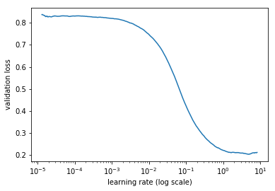

```python
#Code for Satellile Mulilabel
learn.sched.plot()
```

```python
#Code for Satellile Mulilabel
lr = 0.2
learn.fit(lr, 3, cycle_len=1, cycle_mult=2)
```

```
epoch      trn_loss   val_loss   f2
    0      0.14812    0.13372    0.882026
    1      0.143936   0.127549   0.888915
    2      0.13852    0.125587   0.891224
    3      0.141993   0.125718   0.890584
    4      0.134496   0.122519   0.894857
    5      0.133581   0.121666   0.895146
    6      0.132454   0.1213     0.89656
```

```
[array([0.1213]), 0.896560467018689]
```

[lr/9, lr/3, lr] — this is because the images are unlike ImageNet image and earlier layers are probably not as close to what they need to be.

```python
#Code for Satellile Mulilabel
lrs = np.array([lr/9, lr/3, lr])
learn.fit(lr, 3, cycle_len=1, cycle_mult=2)
```

```
epoch      trn_loss   val_loss   f2
    0      0.132426   0.12094    0.89638
    1      0.130661   0.121585   0.894649
    2      0.132286   0.119985   0.897114
    3      0.131334   0.121251   0.897242
    4      0.132659   0.119495   0.897964
    5      0.127357   0.118902   0.898886
    6      0.125172   0.118916   0.897407
```

```
[array([0.11892]), 0.8974071430659079]
```

```python
#Code for Satellile Mulilabel

learn.unfreeze()
learn.fit(lrs, 3, cycle_len=1, cycle_mult=2)
```

```
epoch      trn_loss   val_loss   f2
    0      0.121355   0.108827   0.909262
    1      0.115845   0.103788   0.913543
    2      0.106559   0.10027    0.916651
    3      0.113471   0.101325   0.914635
    4      0.107894   0.098293   0.917484
    5      0.099353   0.097175   0.919561
    6      0.100211   0.09667    0.918813
```

```
[array([0.09667]), 0.9188129076398789]
```

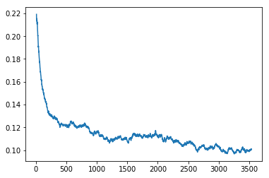

```python
learn.sched.plot_loss()
```

The larger the batch size the more memory you need. The smaller the batch size the more updates you need. You need to find the best compromise. Using batches improves generalisation error. For small data se use small batch size

```python
sz = 128
learn.set_data(get_data(sz))
learn.freeze()
learn.fit(lr, 3, cycle_len=1, cycle_mult=2)
```

```
epoch      trn_loss   val_loss   f2
    0      0.100011   0.09492    0.91839
    1      0.097365   0.093403   0.920757
    2      0.098998   0.093194   0.920245
    3      0.096627   0.093118   0.919972
    4      0.094624   0.092131   0.921998
    5      0.095394   0.091485   0.922416
    6      0.093868   0.091694   0.922217
```

```
[array([0.09169]), 0.9222166576836578]
```

```python
learn.unfreeze()
learn.fit(lrs, 3, cycle_len=1, cycle_mult=2)
learn.save(f'{sz}')
```

```
epoch      trn_loss   val_loss   f2
    0      0.092739   0.087367   0.92694
    1      0.095957   0.087352   0.925994
    2      0.089402   0.084793   0.930144
    3      0.09237    0.087839   0.927889
    4      0.089386   0.085585   0.927609
    5      0.085055   0.083835   0.930375
    6      0.083117   0.083556   0.930293
```

```python
sz = 256
learn.set_data(get_data(sz))
learn.freeze()
learn.fit(lr, 3, cycle_len=1, cycle_mult=2)
```

```
epoch      trn_loss   val_loss   f2
    0      0.090451   0.088095   0.925496
    1      0.091659   0.087742   0.926511
    2      0.088956   0.087192   0.926049
    3      0.089028   0.086548   0.927892
    4      0.088205   0.086538   0.927079
    5      0.088316   0.086237   0.927734
    6      0.085483   0.086138   0.92759
```

```
[array([0.08614]), 0.9275903651441846]
```

```python
learn.unfreeze()
learn.fit(lrs, 3, cycle_len=1, cycle_mult=2)
learn.save(f'{sz}')
```

```
epoch      trn_loss   val_loss   f2
    0      0.083964   0.082358   0.932157
    1      0.088068   0.083394   0.930638
    2      0.080185   0.081334   0.932656
    3      0.089798   0.084523   0.929202
    4      0.082816   0.082401   0.931824
    5      0.082955   0.081272   0.93302
    6      0.079677   0.080974   0.932898
```

```python
log_preds,y = learn.TTA()
preds = np.mean(np.exp(log_preds),0)
f2(preds,y)
```

```
0.4826461087123383
```

```python
multi_preds, y = learn.TTA()
preds = np.mean(multi_preds, 0)
```

```python
f2(preds,y)
```

```
0.9318933119074785
```

# Please do not consider code below

```python
#data=get_data(sz,bs)
```

```python
# On first atempt it may take time to execute precompute action
learn = ConvLearner.pretrained(arch, data, precompute=True)
```

```python
learn.fit(1e-2, 5)
```

```
epoch      trn_loss   val_loss   accuracy
    0      0.940309   0.42377    0.901174
    1      0.435031   0.337902   0.911937
    2      0.294273   0.319067   0.915851
    3      0.230948   0.300107   0.914873
    4      0.206251   0.291623   0.918787
```

```
[array([0.29162]), 0.9187866999328487]
```

## Augment

```python
from sklearn import metrics
```

```python
data=get_data(sz,bs)
```

```python
learn = ConvLearner.pretrained(arch, data, precompute=True, ps=0.5)
```

```python
learn.fit(1e-2, 5)
```

```
epoch      trn_loss   val_loss   accuracy
    0      1.180466   0.440195   0.900685
    1      0.529502   0.344192   0.911448
    2      0.374758   0.296914   0.924168
    3      0.317448   0.287174   0.920254
    4      0.261001   0.29525    0.91683
```

```
[array([0.29525]), 0.9168297432640061]
```

```python
learn.precompute = False
learn.fit(1e-2, 5, cycle_len=1)

# epoch is one pass through the data, a cycle is how many epochs you said is in a cycle
```

```
epoch      trn_loss   val_loss   accuracy
    0      0.318775   0.230907   0.925147
    1      0.295972   0.23538    0.922701
    2      0.279952   0.234568   0.923679
    3      0.260981   0.230398   0.922701
    4      0.254692   0.227181   0.925636
```

```
[array([0.22718]), 0.925636010218973]
```

```python
learn.save('224_pre')
```

```python
learn.load('224_pre')
```

```python
# Starting training on small images for a few epochs, then switching to bigger images,
# and continuing training is an amazingly effective way to avoid overfitting.

# http://forums.fast.ai/t/planet-classification-challenge/7824/96
# set_data doesn’t change the model at all. It just gives it new data to train with.

# If you trained a model on smaller size images, you can then call learn.set_data and pass in a larger size dataset.
# That is going to take your model, however it has been trained so far,
# and it is going to let you continue to train on larger images
learn.set_data(get_data(299, bs))
learn.freeze()

#Source:
#    def set_data(self, data, precompute=False):
#        super().set_data(data)
#        if precompute:
#            self.unfreeze()
#            self.save_fc1()
#            self.freeze()
#            self.precompute = True
#        else:
#            self.freeze()
#File:      ~/fastai/courses/dl1/fastai/conv_learner.py
```

```python
learn.summary()
```

[output not shown]

[output cut: 1441 more lines]

```
                           ('trainable', True),
                           ('nb_params', 1024)])),
             ('Dropout-319',
              OrderedDict([('input_shape', [-1, 512]),
                           ('output_shape', [-1, 512]),
                           ('nb_params', 0)])),
             ('Linear-320',
              OrderedDict([('input_shape', [-1, 512]),
                           ('output_shape', [-1, 120]),
                           ('trainable', True),
                           ('nb_params', 61560)])),
             ('LogSoftmax-321',
              OrderedDict([('input_shape', [-1, 120]),
                           ('output_shape', [-1, 120]),
                           ('nb_params', 0)]))])
```

```python
learn.fit(1e-2,3,cycle_len=1)
```

```
epoch      trn_loss   val_loss   accuracy
    0      0.275769   0.221682   0.930039
    1      0.267356   0.220521   0.928082
    2      0.244732   0.221859   0.924168
```

```
[array([0.22186]), 0.9241682965228236]
```

```python
#As you see, validation set loss (0.2274) is much lower than training set loss (0.28341)
#— which means it is under fitting. When you are under fitting, it means cycle_len=1 is too short
# (learning rate is getting reset before it had the chance to zoom in properly).
# So we will add cycle_mult=2 (i.e. 1st cycle is 1 epoch, 2nd cycle is 2 epochs, and 3rd cycle is 4 epochs)

#Earlier we said 3 is  but it is actually cycles.
# So if cycle_len=2 , it will do 3 cycles where each cycle is 2 epochs (i.e. 6 epochs).
# Then why did it 7? It is because of cycle_mult
# cycle_mult=2 : this multiplies the length of the cycle after each cycle (1 epoch + 2 epochs + 4 epochs = 7 epochs).

learn.fit(1e-2, 3, cycle_len=1, cycle_mult=2)
```

```
epoch      trn_loss   val_loss   accuracy
    0      0.223954   0.217225   0.928571
    1      0.215207   0.217042   0.928571
    2      0.22807    0.216569   0.927104
    3      0.212673   0.213738   0.931507
    4      0.203927   0.212654   0.933464
    5      0.181676   0.209803   0.931507
    6      0.192137   0.210856   0.932975
```

```
[array([0.21086]), 0.9329745634777905]
```

```python
#the validation loss and training loss are about the same — this is about the right track. Then we try TTA
log_preds, y = learn.TTA()
probs = np.mean(np.exp(log_preds),0)
accuracy_np(probs,y), metrics.log_loss(y, probs)

#Other things to try:
#Try running one more cycle of 2 epochs
#Unfreezing (in this case, training convolutional layers did not help in the slightest since the images actually came from ImageNet)
#Remove validation set and just re-run the same steps, and submit that — which lets us use 100% of the data.
```

```
(0.9329745596868885, 0.20374681572909992)
```

```python
len(data.val_ds.y), data.val_ds.y[:5]
```

```
(2044, array([19, 15,  7, 99, 73]))
```

```python
learn.save('229_pre')
```

```python
learn.load('299_pre')
```

```python
learn.fit(1e-2,1,cycle_len=2)
```

```
epoch      trn_loss   val_loss   accuracy
    0      0.186255   0.214761   0.928571
    1      0.166365   0.208221   0.932485
```

```
[array([0.20822]), 0.932485325579074]
```

```python
learn.save('229_pre')
```

```python
log_preds, y = learn.TTA()
probs = np.mean(np.exp(log_preds),0)
accuracy_np(probs,y), metrics.log_loss(y, probs)
```

```
(0.9408023483365949, 0.20083211896166764)
```

This dataset is so similar to ImageNet dataset. Training convolution layers doesn't help much. We are not going to unfreeze.

# Create submission

```python
#To create the submission files on kaggle ( as per kaggle evauation ), we need two pieces of information:

# data.classes : contains all the different classes
# data.test_ds.fnames : test file names
```

```python
data.classes
```

```
['affenpinscher',
 'afghan_hound',
 'african_hunting_dog',
 'airedale',
 'american_staffordshire_terrier',
 'appenzeller',
 'australian_terrier',
 'basenji',
 'basset',
 'beagle',
 'bedlington_terrier',
 'bernese_mountain_dog',
 'black-and-tan_coonhound',
 'blenheim_spaniel',
 'bloodhound',
 'bluetick',
 'border_collie',
 'border_terrier',
 'borzoi',
 'boston_bull',
 'bouvier_des_flandres',
 'boxer',
 'brabancon_griffon',
 'briard',
 'brittany_spaniel',
 'bull_mastiff',
 'cairn',
 'cardigan',
 'chesapeake_bay_retriever',
 'chihuahua',
 'chow',
 'clumber',
 'cocker_spaniel',
 'collie',
 'curly-coated_retriever',
 'dandie_dinmont',
 'dhole',
 'dingo',
 'doberman',
 'english_foxhound',
```

[output cut: 65 more lines]

```
 'standard_poodle',
 'standard_schnauzer',
 'sussex_spaniel',
 'tibetan_mastiff',
 'tibetan_terrier',
 'toy_poodle',
 'toy_terrier',
 'vizsla',
 'walker_hound',
 'weimaraner',
 'welsh_springer_spaniel',
 'west_highland_white_terrier',
 'whippet',
 'wire-haired_fox_terrier',
 'yorkshire_terrier']
```

```python
data.test_ds.fnames
```

```
['test/de084b830010b6107215fef5d4a75b94.jpg',
 'test/6b423ca7020e70eb05732843c5d2bad1.jpg',
 'test/74aa7e201e0e93e13e87b986a7d31839.jpg',
 'test/a079f72193264bc5685e5d28d7372680.jpg',
 'test/583f7580fa5fec1266331fcf83b76fd6.jpg',
 'test/72cd7496a319c832f670fbb8d349217e.jpg',
 'test/ed9e75a553dbb4712addc1638693dc03.jpg',
 'test/6322fa7edb40af844609b4843a89b5fd.jpg',
 'test/d18de4f66f7d2ae8dffb08ec13b9bbc5.jpg',
 'test/8c567325012bf8d7daeff453ec959312.jpg',
 'test/bbecb2e61f07719abe32be3f36b3fac0.jpg',
 'test/7d3a1066521da895f915af31e8e739df.jpg',
 'test/a0256a9577f2e7c6631dd78556e4bab8.jpg',
 'test/87dafc44ed8ae792ea5c341d7cbb6df4.jpg',
 'test/1f2e9080823a6b093e7a4baa668393d2.jpg',
 'test/c65172e587bf02794e5b40f830bcb2af.jpg',
 'test/4f0b2dbc23fdef5f939144f456a62140.jpg',
 'test/a5049952a1a2ea0473e6520db5e4a4fb.jpg',
 'test/685ac2356ad42163b2141a41972e5c54.jpg',
 'test/bd405393e16688e5282b57d92bdbb97b.jpg',
 'test/cbb4039e5a16f80c02f3d188f98beaf7.jpg',
 'test/18cf06b0c6a59c6891bf6f5a42bcc73d.jpg',
 'test/9ec769e34bc902bd9de458103e9347c8.jpg',
 'test/14dac63a8e92005b685c7d39ddd8ed40.jpg',
 'test/c5ebdbaf77a7d833edfde7061bbb21d8.jpg',
 'test/161b2a67618d2217940282d01d27c32a.jpg',
 'test/74b133bbc2d4ece626394bdec13d702a.jpg',
 'test/bfbadb3ef3dc0635a5a0fd800fe456b1.jpg',
 'test/7a82374b96dd6ff135e84a079e4433d0.jpg',
 'test/2e57d925d44dc59983f4fe979f78d505.jpg',
 'test/4ded44ea906ddaeaff15eb82965a14d8.jpg',
 'test/fb2cb63322ef0e9a7ade9ecd93921eb2.jpg',
 'test/9d4d5b37e1be32393d4d36014587d0fd.jpg',
 'test/e702ddff98bd0b05ab200ffb43fb080a.jpg',
 'test/1799b329a758f8f9411337f44a7765de.jpg',
 'test/014da249523b906a840f8c33ae055cf3.jpg',
 'test/d7a8e33d60c6184bdedf9e2e8865199d.jpg',
 'test/844ecf21ddef99656d7829d1e139f9fa.jpg',
 'test/6c9d748c5a472b7f2d51a8f08ac294a8.jpg',
 'test/e9fda9f4a21d4249b9d4a77d06ad751a.jpg',
```

[output cut: 946 more lines]

```
 'test/f3228d0cf1dd0163bb365717eb0254f0.jpg',
 'test/1cb39487e071702fb2ac1a31be2d31d7.jpg',
 'test/7c394506535c7b64949e79db570f9f08.jpg',
 'test/26623886ae122bc7f5e181d331e3683f.jpg',
 'test/192ecd8b7dfafe05b8059125628c9c26.jpg',
 'test/4f5ef91d33d35b31d91e2fe250bc88cb.jpg',
 'test/8a918d65fa1080f9b68b720e72a0575e.jpg',
 'test/8c5442d028fdf92119a23980f1ae2885.jpg',
 'test/69af491274e314d7e03785508d2c507c.jpg',
 'test/576a5cd8fc622937c28fb3082899b411.jpg',
 'test/ee0582b96b135f5e036e011d53baa087.jpg',
 'test/bc45ad24fc667776a43785b1ae0dc906.jpg',
 'test/ee0bd39d8d6a0f57d626dbe1e4c52ebb.jpg',
 'test/e241e149039740594a6af60dc18b269b.jpg',
 ...]
```

```python
# It is always good idea to use TTA:

# is_test=True : it will give you predictions on the test set rather than the validation set

# By default, PyTorch models will give you back the log of the predictions,
# so you need to do np.exp(log_preds) to get the probability.

log_preds, y = learn.TTA(is_test=True) # use test dataset rather than validation dataset
probs = np.mean(np.exp(log_preds),0)
#accuracy_np(probs, y), metrcs.log_loss(y, probs) # This does not make sense since test dataset has no labels
```

```python
probs.shape # (n_images, n_classes)
```

```
(10357, 120)
```

```python
# Create Pandas DataFrame
# Set the column name as data.classes

df = pd.DataFrame(probs)
df.columns = data.classes
```

```python
# Insert a new column at position zero named id.
# Remove first 5 and last 4 letters since we just need IDs
# (a file name looks like test/0042d6bf3e5f3700865886db32689436.jpg)

df.insert(0, 'id', [o[5:-4] for o in data.test_ds.fnames])
```

```python
df.head()
```

|  | id | affenpinscher | afghan_hound | african_hunting_dog | airedale | american_staffordshire_terrier | appenzeller | australian_terrier | basenji | basset | ... | toy_poodle | toy_terrier | vizsla | walker_hound | weimaraner | welsh_springer_spaniel | west_highland_white_terrier | whippet | wire-haired_fox_terrier | yorkshire_terrier |
| --- | --- | --- | --- | --- | --- | --- | --- | --- | --- | --- | --- | --- | --- | --- | --- | --- | --- | --- | --- | --- | --- |
| 0 | de084b830010b6107215fef5d4a75b94 | 1.839555e-07 | 2.770843e-07 | 2.672209e-07 | 4.218459e-08 | 1.774448e-08 | 2.638647e-08 | 9.530575e-09 | 1.846302e-08 | 4.337219e-09 | ... | 3.241194e-09 | 3.993044e-09 | 3.652901e-08 | 1.697883e-08 | 1.051290e-06 | 1.897364e-08 | 3.023121e-08 | 1.614941e-06 | 5.673289e-08 | 4.543784e-09 |
| 1 | 6b423ca7020e70eb05732843c5d2bad1 | 1.134395e-06 | 4.611829e-06 | 1.149696e-07 | 9.743508e-07 | 7.444205e-08 | 8.837860e-09 | 1.875275e-07 | 1.149770e-08 | 1.192066e-07 | ... | 6.582037e-08 | 3.888425e-08 | 3.498506e-08 | 6.333106e-09 | 8.460881e-09 | 5.081928e-08 | 1.903661e-06 | 7.353128e-09 | 5.782406e-07 | 5.293671e-08 |
| 2 | 74aa7e201e0e93e13e87b986a7d31839 | 1.279688e-06 | 4.460341e-06 | 1.082304e-05 | 1.855638e-03 | 6.561762e-06 | 4.478655e-06 | 7.317323e-06 | 2.442026e-05 | 1.059228e-05 | ... | 4.360386e-06 | 5.058888e-06 | 1.370231e-05 | 5.661538e-06 | 9.223229e-06 | 1.890198e-05 | 2.815091e-05 | 4.734738e-05 | 1.077091e-01 | 8.178598e-07 |
| 3 | a079f72193264bc5685e5d28d7372680 | 1.925514e-04 | 8.267522e-06 | 1.185407e-05 | 4.316583e-05 | 6.416438e-06 | 2.115816e-06 | 2.917100e-05 | 1.390391e-06 | 8.485767e-06 | ... | 7.180274e-06 | 1.356116e-05 | 9.694873e-06 | 5.232930e-07 | 1.645602e-05 | 1.392728e-05 | 7.688791e-05 | 6.030944e-06 | 1.852004e-03 | 8.707495e-05 |
| 4 | 583f7580fa5fec1266331fcf83b76fd6 | 3.256468e-06 | 4.258604e-08 | 4.000639e-07 | 4.509840e-07 | 1.668915e-07 | 7.796936e-07 | 5.408355e-09 | 1.794546e-08 | 2.778666e-09 | ... | 5.196585e-08 | 5.960914e-09 | 1.309189e-08 | 3.951142e-09 | 2.893861e-08 | 3.414138e-08 | 2.425930e-09 | 9.455172e-07 | 1.310763e-06 | 7.693014e-08 |

5 rows × 121 columns

```python
# Now you can call ds.to_csv to create a CSV file
# and compression='gzip' will zip it up on the server.
```

```python
SUBM = f'{PATH}/subm/'
os.makedirs(SUBM, exist_ok=True)
df.to_csv(f'{SUBM}subm.gz', compression='gzip', index=False)
```

```python
# You can use Kaggle CLI to submit from the server directly,
# or you can use FileLink which will give you a link to download the file from the server to your computer.
```

```python
FileLink(f'{SUBM}subm.gz')
```

/home/paperspace/fastai/courses/SelfCodes/Dog_breeds_classf/data//subm/subm.gz